```python
%%html
<style>
table {margin-left: 0 !important;align:left;text-align:left}
img { padding-left: 20px; padding-right: 20px}
</style>
```

```python
import sys
!{sys.executable} -m pip install numpy | grep -v 'already satisfied'
!{sys.executable} -m pip install matplotlib | grep -v 'already satisfied'
!{sys.executable} -m pip install ipywidgets | grep -v 'already satisfied'

import numpy as np

import matplotlib.pyplot as plt

import ipywidgets as widgets
from IPython.display import display, HTML


javascript_functions = {False: "hide()", True: "show()"}
button_descriptions  = {False: "Show code", True: "Hide code"}


def toggle_code(state):

    """
    Toggles the JavaScript show()/hide() function on the div.input element.
    """

    output_string = "<script>$(\"div.input\").{}</script>"
    output_args   = (javascript_functions[state],)
    output        = output_string.format(*output_args)

    display(HTML(output))


def button_action(value):

    """
    Calls the toggle_code function and updates the button description.
    """

    state = value.new

    toggle_code(state)

    value.owner.description = button_descriptions[state]


state = False
toggle_code(state)

button = widgets.ToggleButton(state, description = button_descriptions[state])
button.observe(button_action, "value")

display(button)
```

# Cryptalt's Crypto Compendium

A concise overview of crypto assets, investing, and learning resources.

Best viewed at: https://cryptalt.github.io/cryptalt-crypto-compendium/

## Introduction

Disclaimers

Goals

## Mindset

Virtues

Cognitive Biases

## Investing

Investing Basics

Compound Interest

Buying and Selling

## Risk

Risks

Risk Management

Portfolio Allocation

## Taxes

Taxes

## Laws

Laws

## Crypto

Defi

## Links

Recommended Resources

# Disclaimers

[figure not shown]

## Not advice

None of this guide constitutes financial advice, and is only for information and entertainment purposes. Please consult with the appropriate professionals concerning investment decisions, laws, and taxes.

All projects mentioned are for example purposes only. No specific crypto projects or currencies are endorsed by this guide.

## Intellectual Property

This project, including all of the files and their contents, is licensed under the terms of MIT License. See license.txt for details.

This is a freely given work in progress. Suggestions, feedback, and contributions are welcome provided they are given freely relinquishing all restrictions on use including copyright.

Any images or quotes used retain the respective copyright of their owners and are used under fair use. Requests from copyright holders to remove quotes, content, links, or images will be respected.

Contact: https://twitter.com/cryptaltd

[figure not shown]

## Scams

- Never send crypto to anyone who asks for money or promises return, especially if they are claiming to be me. I will never ask you for money.
- Never enter your seed phrase into any website.
- Assume everyone in crypto has an ulterior motive or is trying to scam you.
- Assume all email links or search engine results are phishing attempts.
- Assume wallet plugins/wallet software are trying to steal your seed phrase and coins.

## Accountability

Do your own research. Own your portfolio. Own your future. No excuses.

# Goals

[figure not shown]

- To explain the values, principles, mental models, and strategies for successful crypto investing.
- To be a starting map of the journey to do your own research (DYOR). To show some of the questions to ask and where you can research more answers.
- To fully embrace the principles of WAGMI (We're all going to make it), rejecting the zero-sum belief that for one of us to win someone else needs to lose. A rising tide lifts all boats. Even though there are winners and losers for individual trades, over time crypto is creating exponential value by solving real problems and disrupting real industries through greater innovation, efficiency, and security.
- To encourage the spirit of GM (Good morning) — to celebrate the courage, wisdom, and success of those willing to do take ownership of their own future by taking managed risks and doing the work.
- To help protect investors from scams, ignorance, fear, greed, and malice. Anyone who has been in crypto for any length of time has made mistakes which has cost them painfully large amounts. May you be more successful, and may your failures may have a smaller price.

# Virtues

[figure not shown]

Your success depend more on your discipline, and control over your emotions than your intellect.

Being smart is good. Awareness of yourself, your emotions, and the market is better.

## Patience

> "the wise ones bet heavily when the world offers them that opportunity. They bet big when they have the odds. And the rest of the time, they don’t. It’s just that simple."  
> — Charlie Munger

> “The trick in investing is just to sit there and watch pitch after pitch go by and wait for the one right in your sweet spot. And if people are yelling, ‘Swing, you bum!,’ ignore them.”  
> — Warren Buffet

> "It never was my thinking that made the big money for me. It always was my sitting. Got that? My sitting tight! It is no trick at all to be right on the market. You always find lots of early bulls in bull markets and early bears in bear markets. I’ve known many men who were right at exactly the right time, and began buying or selling stocks when prices were at the very level which should show the greatest profit. And their experience invariably matched mine–that is, they made no real money out of it. Men who can both be right and sit tight are uncommon."  
> — Edwin Lefevre, Reminisces of a Stock Operator

## Focus

[figure not shown]

> “You don’t have to be an expert on every company, or even many,” he says. “You only have to be able to evaluate companies within your circle of competence. The size of that circle is not very important; knowing its boundaries, however, is vital.”  
> — Warren Buffet

> "Use your specialized knowledge to home in on stocks you can analyze, study them and then decide if they’re worth owning. The best way to invest is to look at companies competing in the field where you work. Someone with deep restaurant-industry experience would have predicted the success of Panera Bread Co. and Chipotle Mexican Grill Inc., he says: “If you’re in the steel industry and it ever turns around, you’ll see it before I do."  
> — Peter Lynch

## Cognitive Biases

### Incentive Bias — Conflict of interest

[figure not shown]

Be extremely skeptical of any recommendation to buy anything. Many or most of those shilling projects have powerful incentives to lie to you, and themselves about the future of any project. Most projects will not "go to the moon", and will eventually go to $0.

> “If you can't understand why someone is doing something, look at the consequences of their actions, whatever they might be, and then infer the motivations from their consequences.”  
> —Jordan Peterson

Media and social media are filled with paid promotions, many undisclosed. They are either being paid to lie to you, or being paid to dump their payment in coins on you. If someone is telling you to buy, they probably bought it at a much lower price.

> "Consider the presentations of brokers selling commercial real estate and businesses. I’ve never seen one that I thought was even within hailing distance of objective truth. In my long life, I have never seen a management consultant’s report that didn’t end with the same advice: “This problem needs more management consulting services.” Widespread incentive-caused bias requires that one should often distrust, or take with a grain of salt, the advice of one’s professional advisor, even if he is an engineer.  
> The general antidotes here are:  
> (1) especially fear professional advice when it is especially good for the advisor;  
> (2) learn and use the basic elements of your advisor’s trade as you deal with your advisor; and  
> (3) double check, disbelieve, or replace much of what you’re told, to the degree that seems appropriate after objective thought."  
> —Charlie Munger, The Psychology of Human Misjudgement

#### Self-deception

[figure not shown]

> Above all, don’t lie to yourself. The man who lies to himself and listens to his own lie comes to a point that he cannot distinguish the truth within him, or around him, and so loses all respect for himself and for others. And having no respect he ceases to love.”  
> —Fyodor Dostoevsky, The Brothers Karamazov

If you own anything, you are already subject to incentive bias. This can cause you to make the following costly mistakes:

- not taking profit
- adding to your losers
- cutting your winners instead of letting them run

#### Ownership - the cure for laziness

[figure not shown]

> “Taking complete ownership of your outcomes by holding no one but yourself responsible for them is the most powerful thing you can do to drive your success.”  
> — Gary W. Keller

#### Resources on cognitive bias

| The Psychology of Human Misjudgement - Charlie Munger |  |
| --- | --- |
| Summary Article | https://www.fool.com/investing/general/2013/06/10/charlie-mungers-18-biases-that-cause-you-to-fool-y.aspx |
| Video | https://www.youtube.com/watch?v=pqzcCfUglws |
| Transcript | https://fs.blog/great-talks/psychology-human-misjudgment/ |

# Investing Basics

## Interest

| Terrm | Meaning |
| --- | --- |
| Debt | Money owed - |
| Asset | Money owned + |
| Principal | The initial amount before any interest |
| Interest | Percent added to balance of the debt or asset at fixed interval |
| Compound Interest | Interest on the new balance, which is higher due to previous interest. |
| APR | Annual percentage rate of interest excluding compound interest |
| APY | Annual percentage yield of interest including compound interest. APY is higher than APR |
| rate of supply change | the rate at which the supply of a currency changes. This can be linear, decreasing or dynamic |
| inflation | The rate of decrease in the purchasing power of a currency. High increases in the supply of a currency typically cause high inflation |

## APR vs APY

The larger the APR, the larger the difference between APR and APY When comparing rates, be sure you are comparing APR to APR, or APY to APY

| APR | APY |
| --- | --- |
| 10% | 10.5% |
| 100% | 171.5% |
| 200% | 635% |
| 500% | 14,246% |

Site for converting APR <-> APY: https://www.aprtoapy.com/

# Compound Interest

## The formula for wealth

[figure not shown]

> *Compound interest is the most powerful force in the universe. He who understands it, earns it; he who doesn’t, pays it.*

Nothing is more important to your financial future than benefitting from compound interest.

Every \$1 invested has the potential to become \\$100 or more. A penny saved is a dollar earned. Spend less. Invest more. You can either compound your wealth or compound your debt.

Almost all wealth in the world is the result of compound interest over long periods of time. Wealth goes to those who patiently buy the strongest assets at a good price and hold them for years or decades.

> It's far better to buy a wonderful company at a fair price than a fair company at a wonderful price.  
> — Warren Buffet

## Compounding: high APR for long time

[figure not shown]

The amount of money you start with is important, but the sustained rate of growth is far more important the longer it has time to compound.  
Be extremely skeptical about claimed APRs. Losing money is negative APR, so you need practice strong risk management about what to buy, when to buy it and when to sell it.

> Rule number 1: Never lose money. Rule number 2: Don't forget rule number 1  
> — Warrent Buffet

[figure not shown]

##### Time compounds exponentially

Doubling the duration, however can increase your amount by more than 70x, depending on the APR and duration.

[output not shown]

Any difference increase in APR compounds very rapidly. The difference between 30% and 20% returns is much more than between 20% and 10%.

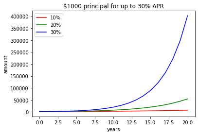

```python
p = 1000
n = 365
t = np.arange(0.0, 21.0, 1.0)

def compound_interest(p, r, n, t):
    return p * (1 + r/n)**(n*t)

def ten_percent(t):
    return compound_interest(p, 10/100, n, t)

def twenty_percent(t):
    return compound_interest(p, 20/100, n, t)

def thirty_percent(t):
    return compound_interest(p, 30/100, n, t)

# Plotting both the curves simultaneously
plt.plot(t, ten_percent(t), color='r', label='10%')
plt.plot(t, twenty_percent(t), color='g', label='20%')
plt.plot(t, thirty_percent(t), color='b', label='30%')

# Naming the x-axis, y-axis and the whole graph
plt.xlabel("years")
plt.ylabel("amount")
plt.title("$1000 principal for up to 30% APR")

#plt.xlim([0, 20])
# Adding legend, which helps us recognize the curve according to it's color
plt.legend()

# To load the display window
plt.show()

state = False
toggle_code(state)
```

Crypto investments have the potential for average triple digit APRs over 4-6 year periods. You can see the 150% APR absolutely dwarfs the 100% APR in only 6 years.

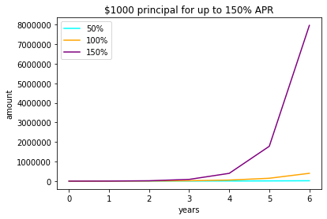

```python
p = 1000
n = 365
t = np.arange(0.0, 7.0, 1.0)

def compound_interest(p, r, n, t):
    return p * (1 + r/n)**(n*t)

def fifty_percent(t):
    return compound_interest(p, 50/100, n, t)

def hundred_percent(t):
    return compound_interest(p, 100/100, n, t)

def one_fifty_percent(t):
    return compound_interest(p, 150/100, n, t)


# Plotting both the curves simultaneously
plt.plot(t, fifty_percent(t), color='cyan', label='50%')
plt.plot(t, hundred_percent(t), color='orange', label='100%')
plt.plot(t, one_fifty_percent(t), color='purple', label='150%')

# Naming the x-axis, y-axis and the whole graph
plt.xlabel("years")
plt.ylabel("amount")
plt.title("$1000 principal for up to 150% APR")

#plt.xlim([0, 6])
# Adding legend, which helps us recognize the curve according to it's color
plt.legend()

#fig, ax = plt.subplots()
#ax.ticklabel_format(useOffset=False)

# To load the display window
plt.ticklabel_format(style='plain')
plt.show()

state = False
toggle_code(state)
```

# Buying and Selling

> *You've got to know when to hold 'em Know when to fold 'em Know when to walk away And know when to run*  
> – Kenny Rogers, (The Gambler)

## Automated strategies for Buying

### Lump Sum Investing

> The best time to buy Bitcoin was 5 years ago. The second best time is now.

With lump sum investing, you invest a large sum and never sell, with the goal of maximizing time in the market. Lump sum also involves timing the market. Effective lump sum investing requires timing the market. Since crypto prices regularly crash 30% or more, you don't want to go all-in when prices are near an all-time high.

### Dollar Cost Averaging (DCA)

With dollar cost averaging, you purchase at a regular interval, e.g. weekly, monthly. This can be an extremely effective strategy, especially for new investors or those with limited time or capital. If you are new to investing, or have been losing money trading, strongly consider this strategy.

Advantages of dollar cost averaging

- don't need to time the market
- very little time required
- limits risk
- trains to "buy the dip" instead of panic sell
- uses volatility to lower cost basis

Dollar cost averaging may even outperform a lump sum if the lump sum was bought near a new all time high, as in the December 2017 example below.

[figure not shown]

Source: https://www.coinbase.com/learn/tips-and-tutorials/dollar-cost-averaging

## Automated selling strategies

### Initial investment / Profit ladder

### Buy and Hold (Hodl)

[figure not shown]

With buy and hold, you buy but don't sell. Over long periods of time, this has proven an extremely effective strategy, especially for coins with long-term utility like Bitcoin or Ethereum. Be extremely careful with this strategy. Many coins which used to be in the top 10 marketcap are now worth close to nothing.

[figure not shown]

| Hold Pros | Hold Cons |
| --- | --- |
| Potentially massive returns | Potential drawdowns over 80%. Some coins never recover or go to $0. |
| No taxes |  |
| Simple |  |
| Outperforms most active traders |  |

# Timing the Market

## The problem of timing the market

Calling tops and bottoms in a market is one of the most difficult things possible. The shorter the timeframe, the more difficult to accurately predict. It's easy to tell yourself you will buy the bottom and sell the top, but many investors tend to buy coins that have already pumped and then sell them at a loss when they dump, only to buy them back higher after another pump. Missing even a few of the best performing days can remove most or all of your gains.

### \$10k Investment S&P 500 from 2000-2020

| Best days missed | Dollar Value | Annualized Performance |
| --- | --- | --- |
| Fully invested | \$32,421 | 6.06% |
| Missed 10 best days | \$16,180 | 2.44% |
| Missed 20 best days | \$10,176 | 0.08% |
| Missed 30 best days | \$6,749 | (1.95%) |
| Missed 40 best days | \$4,607 | (3.8%) |
| Missed 50 best days | \$3,246 | (5.47%) |
| Missed 60 best days | \$2,331 | (7.02%) |

> "Beating the stock market is hard. When you're out of the market, you might feel safer, but you risk missing out on huge gains."  
> — [The Motley Fool](https://www.fool.com/investing/2020/12/31/missing-just-a-few-of-the-best-stock-market-days-c/)

## Counter-trading human psychology

In timing the market try to predict when the market will go up or down. Most traders fail horribly at this, especially when taxes are taken into account. It's easy to say you will buy the dip and sell the pump, but the default of human psychology is to do the exact opposite.

> "We think we are wolves, living by the logic of the pack.  
> In truth we are sheep, living by the logic of the flock.  
> Sheep are evolved to have a specific type of intelligence which has the following hallmarks.
> 1. Enormous capacity for other-regarding behaviors.

> Sheep are unbelievably sensitive to what other sheep are doing and their emotional states....
> 2. Zero altruism and overwhelming selfishness....
> 3. The determination to pursue any behavior that meets Hallmark 1 and 2 to absurd ends, even unto death....

> My worst sheep suicide story? The first year we kept sheep, we thought it would make sense to set up a hay net in their pen, which keeps the hay off the ground and lets the sheep feed themselves by pulling hay through the very loose loops of the net. Turned out, though, that the loops were so loose that a determined sheep could put her entire head inside the net, and if one sheep could do that, then two sheep could do that.  
> And given how the hay net was hung and how these sheep were sensing each other, they started to move clockwise in unison, each trying to get an advantage over the other, still with their heads stuck in the net. At which point the net starts to tighten. And tighten. And tighten. My daughter found them the next morning, having strangled each other to death, unable to stop gorging themselves or seeking an advantage from the behavior of others. The other sheep were crowded around, stepping around the dead bodies, pulling hay for themselves out of the net. That was a bad day.  
> In both markets and in politics, our human intelligences are being trained to be sheep intelligences."  
> — https://www.epsilontheory.com/sheep-logic/

To be successful as a trader, you must know yourself, know your own emotions and have an edge in predicting where the market is going. Be very careful using active trading and ensure you are using risk management to preserve your capital.

Active trading techniques attempt to identify market sentiment and momentum to determine areas of high reward to risk.

Popular techniques for active trading include:

- technical analysis of chart patterns to determine market sentiment and momentum
- order flow analysis of buy and sell orders on exchanges
- on-chain metrics for when coins are moved from exchanges to wallets or wallets to exchanges
- market cycle indicators

### Technical Analysis

#### Fear and Greed Index

https://alternative.me/crypto/fear-and-greed-index/

### Market cycle indicators

#### Logarithmic Regression - BTC/ETH rainbow chart

In this strategy, you buy when the price of Bitcoin or Ethereum is significantly below it's logarithmic regression trend (blue/green) and you sell when it's significantly above (orange/red). This strategy can be combined with either lump sum or weighted dollar cost averaging, where the amount you buy increases as the price is "cheap" on the regression model.

There is no guarantee this regression model will hold in the future.

[figure not shown]

Source: https://www.blockchaincenter.net/bitcoin-rainbow-chart/

See also: https://www.blockchaincenter.net/ethereum-rainbow-chart/

#### Pi Cycle Top Indicator

In this strategy, you wait for the value of the 350 daily moving average x2 (orange line) to pass the 111 daily moving averagee (green line) as a sell signal. This indicator has often timed market tops to within a few days.

[figure not shown]

https://www.lookintobitcoin.com/charts/pi-cycle-top-indicator/

# Risks

## Volatility

## Bad Actors

## Rug Pulls

## Security audits and their limits

## Hacks

## Compromised Seed Phrase

## Pump and Dump

# Risk Management

## Debt and Leverage

### Good debt vs bad debt

[figure not shown]

Leverage in crypto trading is one of the fastest way to lose all of your money.

A home mortgage within your budget under 3% APR, by contrast can free up your capital to potentially earn much greater yield in the market.

"Good" Debt

- low interest rate
- used so can invest in long term appreciating assets
- have an emergency fund in place
- can eaily afford payments on, even without income
- collateral backing value (e.g. home)
- low risk of default

"Bad" Debt

- high interest rate
- high probability of liquidation
- requires timing the market

## Not your keys not your coins

## The importance of hardware wallets

## Scaling in and scaling out of a position

## Stop losses - pros and cons

### Riding up with stop losses

# Portfolio Allocation

## Asset Categories

### Stable

### Volatile

#### Inflationary

#### Deflationary

## Types of Assets

| Traditional Asset | APR (avg) | Volatility (avg) |
| --- | --- | --- |
| Stocks Index Fund | 10% | 15% |
| Bond Index Fund | 0%-6% | 1-5% |
| Savings Account | 0% | 0% |

| Crypto Asset | APR (est) | Volatility (est) |
| --- | --- | --- |
| Coin/token | 200% | -95% to 300% |
| Liquidity Farm | 5%-200% | -99% to 600% |
| Stablecoin Yield | 1%-18% | -1% to 1% |

## Underdiverification -- more volatility

## Overdiversification -- average results

## 75%/25% porfolio - The Simple Path to Wealth

## 90%/10% - Barbell portfolio, conservative with upside

## Risk Adjusted Return

# Taxes

Disclaimer: None of the following should be interpreted as professional advice. The following information is related to US taxes. Consult a tax professional licensed for your country/region for any tax questions.

## Strategies for minimizing taxes

### Buy and Hold

### Wash sales and tax loss harvesting

### Loans

### Wrapped assets

#### Wrapped inflationary assets to minimize taxable events

### Charitable Giving

#### Donor Advised Funds

If you donate to charities, one of the best tax incentives it to donate long-term appreciated assets to either a charity directly, or through a donor advised fund (DAF). By donating a long-term appreciated asset, you get double benefits, in that you get the full write-off of the value of what you donated, but since you didn't sell it, you need to pay have capital gains. You can create your on DAF through services like (CharityVest)[https://www.charityvest.org/]. This strategy only applies to long term capital gains: held for 1 year or longer using first-in-first-out (FIFO) accounting.

https://www.charityvest.org/daf-guide

# Laws

Laws are subject to change at any time. Consult a legal or tax professional to ensure compliance with your local laws. See (Disclaimers)[#Disclaimers]

## Know your customer (KYC)

## Anti-money laundering (AML)

## Foreign Bank and Financial Accounts (FBAR)

Holders of foreign crypto accounts are not currently required to file an FBAR for foreign accounts.

> Report of Foreign Bank and Financial Accounts (FBAR) Filing Requirement for Virtual Currency FinCEN Notice 2020-2  
> Currently, the Report of Foreign Bank and Financial Accounts (FBAR) regulations do not define a foreign account holding virtual currency as a type of reportable account. (See 31 CFR 1010.350(c)).  
> For that reason, at this time, a foreign account holding virtual currency is not reportable on the FBAR (unless it is a reportable account under 31 C.F.R. 1010.350 because it holds reportable assets besides virtual currency).  
> However, FinCEN intends to propose to amend the regulations implementing the Bank Secrecy Act (BSA) regarding reports of foreign financial accounts (FBAR) to include virtual currency as a type of reportable account under 31 CFR 1010.350.  
> —https://www.fincen.gov/sites/default/files/shared/Notice-Virtual%20Currency%20Reporting%20on%20the%20FBAR%20123020.pdf

If regulations change to require FBAR for crypto accounts, failure to report would be punishable up to //$10,000 per incident.

Examples of foreign exchanges:

- Binance Global (Not Binance US)
- Kucoin
- Okex

Examples of US based exchanges (non-foreign)

- Coinbase
- FTX
- Kraken
- Bittrex

### Security and Scammers

#### Software Wallets

##### Seed phrases and passwords

#### Hardware Wallets

#### Why paid courses and groups are a waste of money

# Fundamental Analysis

## Tokenomics

### Marketcap

## Coins vs Tokens

## Crypto Values

- Open
- Decentralized
- Monetized Incentivized
- Privacy

## Qualities to look for in a Layer 1 blockchain

- Decentralized
- Scalable
- Interoperable
- Private
- Monetized
- Network effects & Metcalfe's law

## Green flags - Things to look for before investing on a crypto project

- Working product
- Team has created successful projects previously
- Invested in by exchanges or companies with strong track record for success (e.g. Alameda Research, Pantera, Coinbase, Binance)
- Solve significant problem 10x better than competition. The best and most innovative projects have little to no competition.
- Large, addressible market with discretionary income
- Active marketing
- Popular social media lunar crush
- Low enough market cap
- Recent GitHub activity
- Responsive discord

## Red Flags - Reasons to avoid/be skeptical of a crypto project

- does not unqiuely solve an important problem well
- poor governance - all decisions made by single charismatic leader who does not delegate power
- lead developers defensive and do not take feedback critism well
- not audited, or audit excludes contract risk
- copycat - no unique value proposition
- "guaratees" future performance
- very high apr / inflation
- anonymous members who can spend / send / steal funds
- no multi-signature wallet
- consistently misses targets and deadlines
- no recent development activity
- chasing fad

# Defi

## Liquidity - the most valuable part of any market

## Order Book

## AMM Dex

## Liquidity Pool

## Sky-high APR lies and inflation

## Auto-compounding

### Mitigate inflation risk

##### Multi-sig and exploit risk

#### Impermanent Loss

[figure not shown]

> impermanent loss is a temporary loss of funds occurring when providing liquidity. It’s very often explained as a difference between holding an asset versus providing liquidity in that asset. Impermanent loss is usually observed in standard liquidity pools where the liquidity provider (LP) has to provide both assets in a correct ratio, and one of the assets is volatile in relation to the other, for example, in a Uniswap DAI/ETH 50/50 liquidity pool.  
> — https://finematics.com/impermanent-loss-explained/

# Formulas:

## Rule of 72:

*The number of years it takes for your money to double is 72 divided by your interest rate.*

| APR | Years to double |
| --- | --- |
| 4% | 18 years |
| 6% | 12 years |
| 10% | 7.2 years |
| 36% | 2 years |
| 72% | 1 years |
| 144% | 0.5 years |

## Compound Interest

a = p * (1 + r/n)^(nt)

Where a = amount, = principal, r = apr, n = number of compoundings per unit time, t = count of unit time (usually year)

## APR to APY

# Recommended Resources

## Videos

### DYOR - Fundamental Analysis and Tokenomics

- [Coin Bureau - Youtube](https://www.youtube.com/channel/UCqK_GSMbpiV8spgD3ZGloSw)

## Books

### Trading

- [Emperor BTC Trading Manual - PDF](https://drive.google.com/file/d/1W-9XUcTRc1Zerwi6D-ZYTVzRrVbXoVbG/view)
- Reminiscences of a Stock Operator — Edwin Lefèvre

### Portfolio Allocation

- The Simple Path to Wealth — J L Collins

### Mental Models & Cognitive Biases

- Poor Charlie' Almanack — Charlie Munger

### Recommended Twitter Follows

#### market indicators and sentiment

- https://twitter.com/tedtalksmacro

#### Fundamental Analysis

- https://twitter.com/Beastlyorion